# Simulated tumours: single-sample data

Giulio Caravagna and Timon Heide

12/03/2020

```r
require(dplyr)
require(mobster)
```

This page describes the single-sample synthetic data used to test [MOBSTER](https://caravagn.github.io/mobster), where we fixed the simulated tumour sequencing (120x) and purity (100%). Some of these tumours are monoclonal neutral (0 subclones), others have 1 subclone, as discussed in the paper.

The simulations have been collected in an RDS object, for conveniency. A similar dataset is released containing simulations with varying sequencing coverage.

**Note.** Data have been generated using the Tumour Emulator TEMULATOR package developed by [Timon Heide](https://github.com/T-Heide) at the [Sottoriva Lab](http://www.sottorivalab.org/). See the simulator webpage to learn how to generate new sequencing data using a Markov model of stochastic tumour growth.

```r
simulations = readRDS("./asymmetric_branching_simulations_batch1.1.rds")
```

# Available cohort

```r
# Number of simulations
print(length(simulations))
```

```
#> [1] 150
```

```r
# Simulation ids
print(names(simulations) %>% head)
```

```
#> [1] "3cafa2169bda0833c9e0632be1d2130d002c0462"
#> [2] "0ec48aebe4742a607ead695fd223cf52dd8af727"
#> [3] "d5d4e29ab414a89d3fe03bbe88e8d8267f4b4c81"
#> [4] "41578333c4c6ba43e696025d6d3a56056b7d0e7d"
#> [5] "fb740568016cb7b2f59ec67a1991c9d63edccdd4"
#> [6] "dcb8ad3cbaa195e2f0e60df18a7fe302a1543dc2"
```

# Analysis (example case)

We show how to fit one of the simulated cases, tumour `dcf11bece430ee3a98cc76ff0d91d2c67448258d`.

```r
id = 'dcf11bece430ee3a98cc76ff0d91d2c67448258d'

# Simulation data
tumour = simulations[[id]]

# The data structure contains different type of information
print(tumour)
```

```
#> $cell_counts
#>                 total       clone0       clone1
#> counts    107865231.0 9.314523e+06 9.855071e+07
#> fractions         0.5 4.317700e-02 4.568200e-01
#>
#> $adjacency_matrix
#>   V1 V2
#> 1  0  1
#> 2  0  0
#>
#> $clone_parameters
#>   type_number mutation_rate birth_rate death_rates start_time father
#> 1           0            16        1.0         0.2          0      0
#> 2           1            16        1.9         0.2        512      0
#> 3           2             0        0.0         0.0          0      0
#>
#> $simulation_parameters
#>                   Seed               N clones               N clonal
#>           "1521808976"                    "2"                  "500"
#>         Simulation end       Sequencing depth Sequencing depth model
#>            "179782830"                  "120"                    "2"
#>         LOD sequencing
#>                 "0.05"
#>
#> $sequencing
#> # A tibble: 1,075 x 6
#>       VAF   ALT    DP CLONE TRUE_VAF TRUE_CLUSTER
#>     <dbl> <int> <int> <int>    <dbl> <fct>
#>  1 0.0548     8   146     2   0.0377 2dcd
#>  2 0.0566     6   106     2   0.0377 2dcd
#>  3 0.0588     6   102     2   0.0377 2dcd
#>  4 0.0523     9   172     2   0.0377 2dcd
#>  5 0.0596     9   151     2   0.0490 2a68
#>  6 0.0536     6   112     2   0.0490 2a68
#>  7 0.0816    12   147     2   0.0490 2a68
#>  8 0.075      9   120     2   0.0490 2a68
#>  9 0.05       5   100     2   0.0490 2a68
#> 10 0.0667     3    45     2   0.0490 2a68
#> # … with 1,065 more rows
```

Sequencing data - see TEMULATOR for details - is in the format suitable for MOBSTER analysis.

We here fit the model with the fast setup of MOBSTER (`auto_setup = 'FAST'`).

```r
data = tumour$sequencing
head(data) %>% print
```

```
#> # A tibble: 6 x 6
#>      VAF   ALT    DP CLONE TRUE_VAF TRUE_CLUSTER
#>    <dbl> <int> <int> <int>    <dbl> <fct>
#> 1 0.0548     8   146     2   0.0377 2dcd
#> 2 0.0566     6   106     2   0.0377 2dcd
#> 3 0.0588     6   102     2   0.0377 2dcd
#> 4 0.0523     9   172     2   0.0377 2dcd
#> 5 0.0596     9   151     2   0.0490 2a68
#> 6 0.0536     6   112     2   0.0490 2a68
```

```r
# fit by MOBSTER
fit = mobster_fit(data, auto_setup = 'FAST')
```

```
#>  [ MOBSTER fit ]
#> ✔ Loaded input data, n = 1075.
#> ❯ n = 1075. Mixture with k = 1,2 Beta(s). Pareto tail: TRUE and FALSE. Output
#> clusters with π > 0.02 and n > 10.
#> ! mobster automatic setup FAST for the analysis.
#> ❯ Scoring (without parallel) 2 x 2 x 2 = 8 models by reICL.
#> ℹ MOBSTER fits completed in 4.7s.
#> ── [ MOBSTER ] My MOBSTER model n = 1075 with k = 1 Beta(s) and a tail ─────────
#> ● Clusters: π = 62% [C1] and 38% [Tail], with π > 0.
#> ● Tail [n = 402, 38%] with alpha = 1.9.
#> ● Beta C1 [n = 673, 62%] with mean = 0.49.
#> ℹ Score(s): NLL = -1222.42; ICL = -2363.86 (-2402.95), H = 39.09 (0). Fit
#> converged by MM in 11 steps.
```

```r
# Print and plot the fit
print(fit$best)
```

```
#> ── [ MOBSTER ] My MOBSTER model n = 1075 with k = 1 Beta(s) and a tail ─────────
#> ● Clusters: π = 62% [C1] and 38% [Tail], with π > 0.
#> ● Tail [n = 402, 38%] with alpha = 1.9.
#> ● Beta C1 [n = 673, 62%] with mean = 0.49.
#> ℹ Score(s): NLL = -1222.42; ICL = -2363.86 (-2402.95), H = 39.09 (0). Fit
#> converged by MM in 11 steps.
```

We can plot the fit.

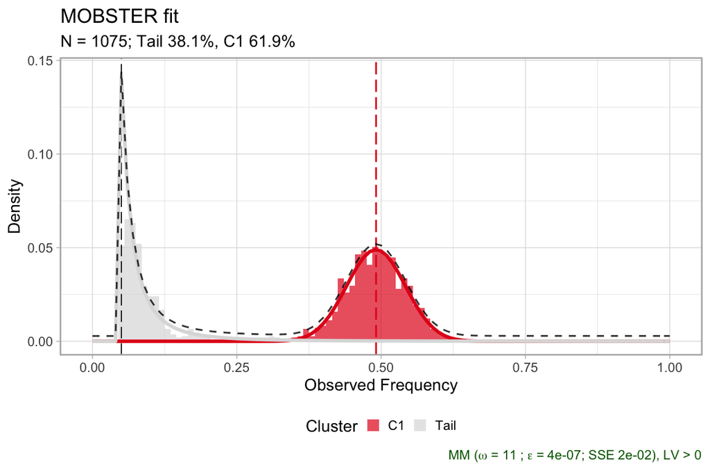

```r
plot(fit$best)
```

```r
clone_peaks = round(tumour$cell_counts['fractions', 3:ncol(tumour$cell_counts)], 3)
clone_peaks = clone_peaks[clone_peaks > 0.05]

clone_peaks = c(clone_peaks, 0.5)

print(clone_peaks)
```

```
#> [1] 0.457 0.500
```

You can conclude that the subclone in this tumour has swept through almost completely (~45% VAF); the fits reports indeed one major clonal expansion (no evidence of ongoing subclonal selection, 1 Beta component).

### A polyclonal tumour (with a detectable subclone expanding)

This example instead shows a clear sign of an ongoing subclonal selection.

```r
id = "9583d8ac804182ed719509e00a1d1d07630a910f"

# fit by MOBSTER
fit = mobster_fit(simulations[[id]]$sequencing, auto_setup = 'FAST')
```

```
#>  [ MOBSTER fit ]
```

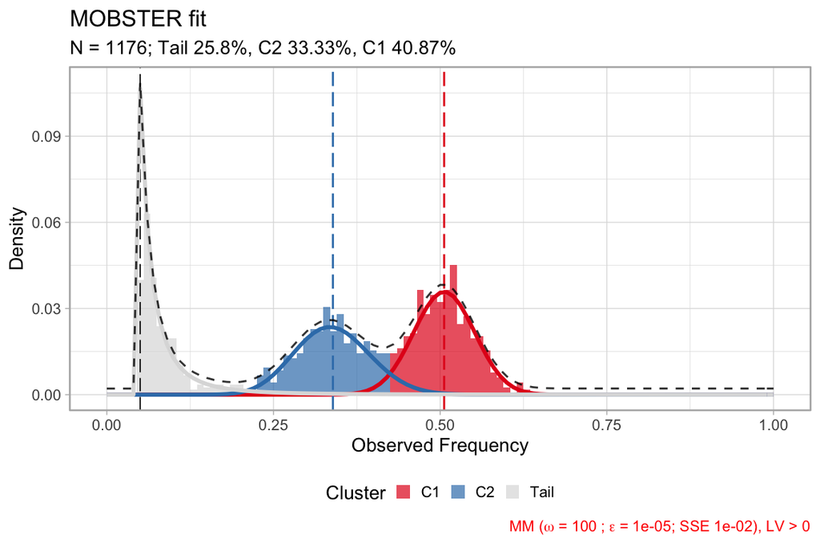

```r
plot(fit$best)
```

The simulated CCF for the subclone is correctly identified

```r
round(
  simulations[[id]]$cell_counts[
    'fractions',
    3:ncol(simulations[[id]]$cell_counts)
    ],
  3) %>%
  print
```

```
#> [1] 0.329
```

```r
print(fit$best)
```

```
#> ── [ MOBSTER ] My MOBSTER model n = 1176 with k = 2 Beta(s) and a tail ─────────
#> ● Clusters: π = 41% [C1], 33% [C2] and 26% [Tail], with π > 0.
#> ● Tail [n = 293, 26%] with alpha = 2.1.
#> ● Beta C1 [n = 490, 41%] with mean = 0.51.
#> ● Beta C2 [n = 393, 33%] with mean = 0.34.
#> ℹ Score(s): NLL = -966.38; ICL = -1689.25 (-1754.83), H = 179.88 (114.3). Fit
#> interrupted by MM in 100 steps.
```